# Lasso + Ridge Regression

Peter Freeman (2019 SLSW)

1 July 2019

# Shrinkage Methods

The lasso and ridge regression are *shrinkage methods* that are alternatives to best subset selection (and to forward or backward stepwise selection). They differ from BSS in that they penalize models in a different manner than BSS does:
$$\begin{eqnarray*}
{\rm lasso:} &~& {\rm RSS} + \lambda \sum_{i=1}^p \vert \beta_i \vert \\
{\rm ridge:} &~& {\rm RSS} + \lambda \sum_{i=1}^p \beta_i^2
\end{eqnarray*}$$

The effects of the additive penalty (or regularization) terms is dictated by the magnitude of the tuning parameter $\lambda$. If $\lambda \rightarrow 0$, then the penalty terms have no effect, and thus the use of lasso and ridge regression is equivalent to simply performing regular old linear regression.

However, if $\lambda \rightarrow \infty$, then…

- lasso: to balance the large value of $\lambda$, all the linear regression coefficients shrink toward zero, but some go to zero more quickly than others; hence lasso performs its own version of subset selection
- ridge: to balance the large value of $\lambda$, all the coefficients shrink toward zero

# Shrinkage Methods

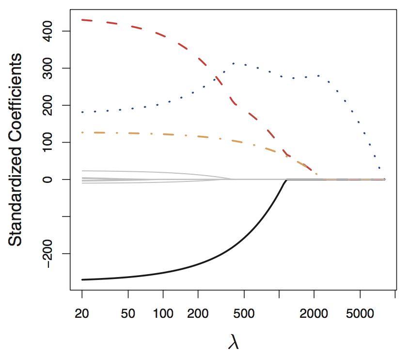

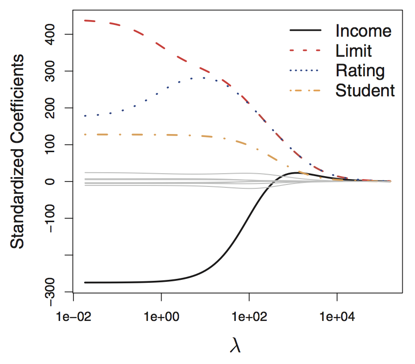

For example: note how the magnitude of the coefficient for `Income` trends as $\lambda \rightarrow \infty$.

In the context of lasso, the coefficient goes to zero at $\lambda ~ 1000$; if the optimum value of $\lambda$ is larger, then `Income` would not be included in the learned model.

In the context of ridge regression, the coefficient shrinks towards zero, but never actually reaches it. `Income` is always a variable in the learned model, regardless of the value of $\lambda$.

While it may seem obvious that lasso is the preferred learning model (since it performs variable selection), realize that ridge regression may yield a small test-set MSE! Depending on circumstance, you may prefer to utilize a model that has $p$ predictor variables, but yields better predictions, over a model that has $k < p$ predictor variables, but yields worse predictions.

# Shrinkage Methods: Caveats

2. $\lambda$ is a tuning parameter. This means that you have to split your training data into training and validation sets, or perform cross-validation on the training data.

(Note that if you utilize the `glmnet` package, the `cv.glmnet()` package will perform the necessary cross-validation for you.)

# Lasso: Regression Example

```r
load(url("https://raw.githubusercontent.com/pefreeman/36-290/master/EXAMPLE_DATASETS/PHOTO_MORPH/photo_morph.Rdata"))
```

The `load()` function places two stored variables into the global environment: `predictors`, a data frame with 16 measurements for each of 3,419 galaxies, and `response`, a vector with 3,419 redshifts (i.e., metrics of physical distance). Because lasso (and ridge regression) is more useful/effective when $n \sim p$, we will analyze only the first 70 objects.

```r
pred.train = predictors[1:50,]
pred.test  = predictors[51:70,]
resp.train = response[1:50]
resp.test  = response[51:70]
```

# Lasso: Regression Example

Here we utilize the `glmnet` package. The functions of `glmnet` are a tad “prickly” in that they don’t abide by the usual rules that apply to model functions in `R`, as you will see. Note that to perform ridge regression, one can perform all the same steps below, except changing the argument `alpha=1` to `alpha=0`. Also note that one can apply lasso and ridge regression in the context of, e.g., binary classification by adding the argument `family="binomial"` to `glmnet()` function calls.

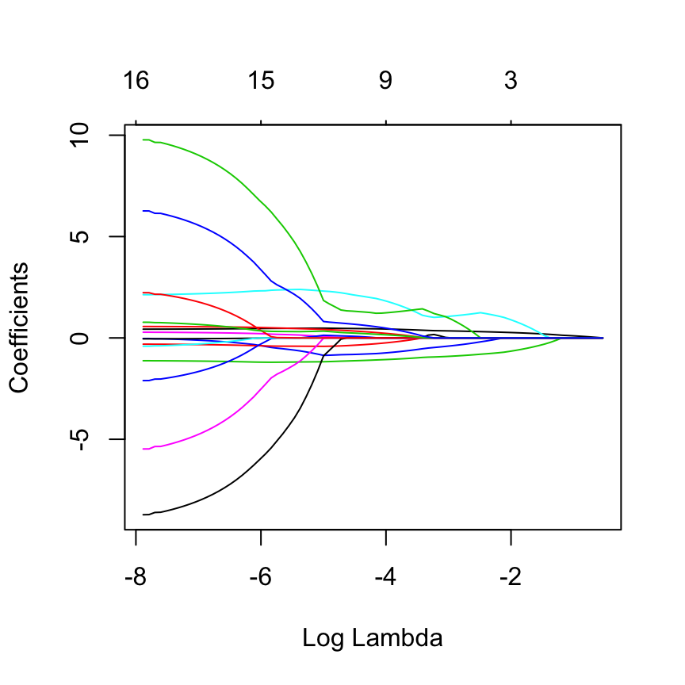

```r
if ( require(glmnet) == FALSE ) {
  install.packages("glmnet",repos="https://cloud.r-project.org")
  library(glmnet)
}
x = model.matrix(resp.train~.,pred.train)[,-1]
y = resp.train
out.lasso = glmnet(x,y,alpha=1)  # alpha = 0: ridge regression; alpha = 1: lasso
plot(out.lasso,xvar="lambda")
```

# Lasso: Regression Example

What is the optimal value of $\lambda$?

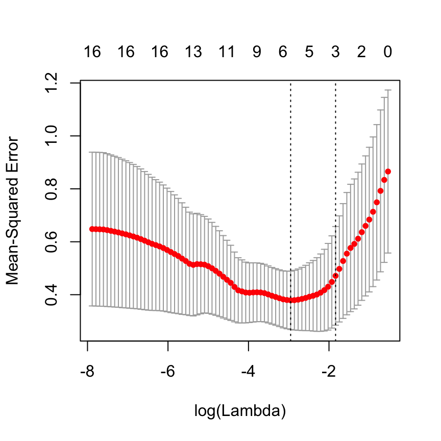

```r
set.seed(301)  # cv.glmnet() performs random sampling...so set the seed!
cv = cv.glmnet(x,y,alpha=1)
plot(cv)
```

```r
cv$lambda.min
```

```
## [1] 0.05220884
```

```r
coef(out.lasso,cv$lambda.min)
```

```
## 17 x 1 sparse Matrix of class "dgCMatrix"
##                      1
## (Intercept)  1.8554189
## mag.i        0.3443019
## col.Vi       .
## col.iJ      -0.9018567
## col.JH      -0.3869856
## V.G          1.0767727
## V.M20        .
## V.C          .
## V.size       .
## J.G          0.9164856
## J.M20        .
## J.C          .
## J.size       .
## H.G          .
## H.M20        .
## H.C          .
## H.size       .
```

# Lasso: Regression Example

```r
x.test    = model.matrix(resp.test~.,pred.test)[,-1]
resp.pred = predict(out.lasso,s=cv$lambda.min,newx=x.test)
mean((resp.pred-resp.test)^2)
```

```
## [1] 0.4393626
```

# Lasso: Classification Example

The dataset that we read in below contains magnitude and redshift data for 500 quasars and 500 stars. The idea is to learn a classifier that can discriminate between quasars and stars with a low misclassification rate.

```r
df = read.csv("https://raw.githubusercontent.com/pefreeman/PSU_2019/master/StarQuasar.csv")
dim(df)
```

```
## [1] 1000    8
```

```r
names(df)
```

```
## [1] "u.mag"        "g.mag"        "r.mag"        "i.mag"
## [5] "z.mag"        "redshift"     "redshift.err" "class"
```

```r
set.seed(202)
s = sample(nrow(df),0.7*nrow(df))
pred.train = df[s,1:5]                                  # don't include redshift or redshift error!
pred.test  = df[-s,1:5]
resp.train = df[s,8]
resp.test  = df[-s,8]
```

# Lasso: Classification Example

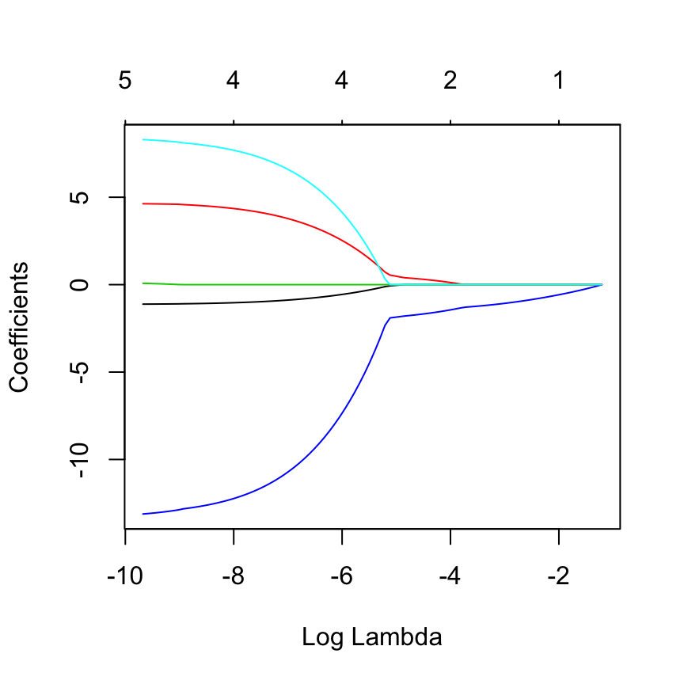

```r
x = model.matrix(resp.train~.,pred.train)[,-1]
y = resp.train
out.lasso = glmnet(x,y,alpha=1,family="binomial")  # note the "family" argument
plot(out.lasso,xvar="lambda")
```

# Lasso: Classification Example

What is the optimal value of $\lambda$? (Here, it is very small…meaning there is no reason to favor lasso over logistic regression. This is no surprising given the relative size of the training set [700] to the number of predictors [5].)

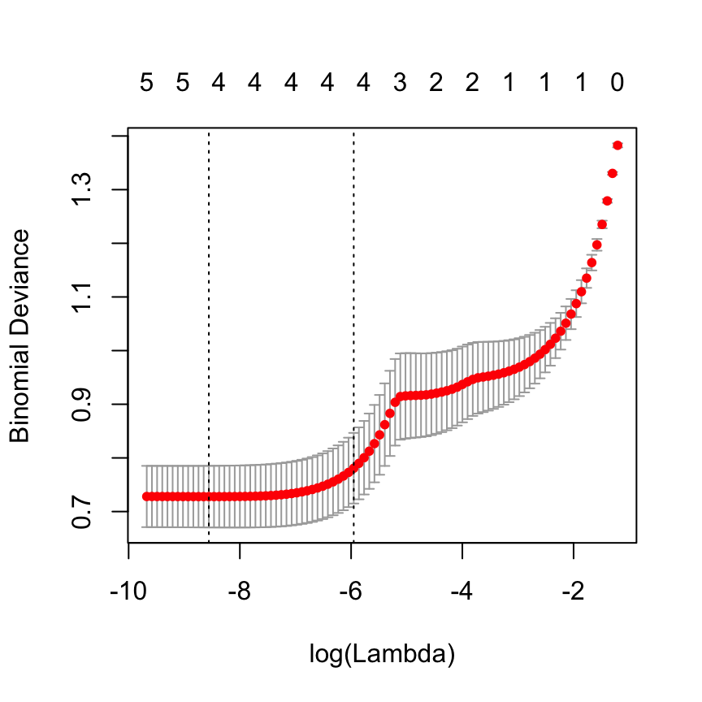

```r
set.seed(302)
cv = cv.glmnet(x,y,alpha=1,family="binomial")
plot(cv)
```

```r
cv$lambda.min
```

```
## [1] 0.0001920768
```

```r
coef(out.lasso,cv$lambda.min)
```

```
## 6 x 1 sparse Matrix of class "dgCMatrix"
##                      1
## (Intercept)  23.608232
## u.mag        -1.076148
## g.mag         4.510210
## r.mag         .
## i.mag       -12.646432
## z.mag         7.983341
```

# Lasso: Classification Example

```r
x.test    = model.matrix(resp.test~.,pred.test)[,-1]
resp.prob = predict(out.lasso,s=cv$lambda.min,newx=x.test,type="response")
resp.pred = ifelse(resp.prob>0.5,"STAR","QSO")
mean(resp.pred!=resp.test) # basically the same as for logistic regression
```

```
## [1] 0.1533333
```

```r
table(resp.pred,resp.test)
```

```
##          resp.test
## resp.pred QSO STAR
##      QSO  135   24
##      STAR  22  119
```